# Project1

Kumar Aiyer

01/15/2016

Load and transform the data for the analysis

```r
options(width=120)

#
# write a function geteloaddatadf() - you will assign the return value to eloaddf
# in the function do the following
# 1. load the electric load data from elecloaddata.xlsx
# you are not allowed to convert to .csv. Find an appropriate R package that can read .xlsx files and load
# the data in a dataframe called eloaddf. The columns should be dates, kwh, kwVAR
#
# some notes on the data
# the file has 15 min interval data from 1/1/2014 to 12/30/2015
# when you import the data, the first column of your dataset should be dates in POSIXct format
# HINT: use the strptime and as.POSIX.ct functions to form the eloaddf$dates

# This library will allow R to read .xlsx files and load them
library(openxlsx)

# Converts numeric date to character date for elec data
formatelecDate = function(date)
{
  c.date = paste(paste(as.integer(date/10000), as.integer(date/100) %% 100, sep = "/"), date %% 100, sep = "/");

  return(c.date);
}

# Converts numeric time to character time for elec data
formatelecTime = function(time)
{
  seconds = 0;
  minutes = time %% 100;
  hours = as.integer(time/100);

  c.time = paste(paste(hours, minutes, sep = ":"), seconds, sep = ":");

  return(c.time)
}

geteloaddatadf = function()
{
  data = read.xlsx("elecloaddata.xlsx")
  data$DATE = formatelecDate(data$DATE);
  data$TIME = formatelecTime(data$TIME);

  eloaddf = data.frame(dates = as.POSIXct(strptime(paste(data$DATE, data$TIME), "%m/%d/%y %H:%M:%S"), tz = "GMT"), kwh = data$kWh, kwVAR = data$kVARh);

  return(eloaddf)
}

eloaddf = geteloaddatadf();

#
# write a function getweatherdf() - you will assign the return value to weatherdf
# 2. Next load the weather data from NOAA into a data frame weatherdf. The data is in 1874606932872dat.txt
# This is 1 hour interval data for a specific weather station close to
# the location of the site from which electric load data was obtained
#
# you need to use fixed width parsing to read the data into a data frame.
# add a column called dates to the dataframe similar to #1 above
#

# library to read in fixed columns
library(readr)

# Converts numeric date to character date for weather data
formatweathDate = function(date)
{
  c.date = paste(paste(as.integer(date/1000000) %% 100, as.integer(date/10000) %% 100, sep = "/"), as.integer(date/100000000), sep = "/");

  return(c.date);
}

# Converts numeric time to character time for weather data
formatweathTime = function(time)
{
  seconds = 0;
  minutes = time %% 100;
  hours = as.integer(time/100) %% 100;

  c.time = paste(paste(hours, minutes, sep = ":"), seconds, sep = ":");

  return(c.time)
}

# took some iformation from 3505doc.txt
getweatherdf = function()
{
  data = read_fwf("1874606932872dat.txt", skip = 1, na = c("*", "**", "***", "****", "*****"),
                  fwf_widths(c(7, 6, 13, 4, 4,
                               4, 4, 4, 2, 2, 2, 5,
                               3, 3, 3, 3, 3, 3, 3, 3,
                               2, 5, 5, 7, 6, 7,
                               4, 4, 6, 6, 6, 6, 2)));
  names(data) = c("USAF", "WBAN", "YR__MODAHRMN", "DIR", "SPD",
                "GUS", "CLG", "SKC", "L", "M", "H", "VSB",
                "MW.1", "MW.2", "MW.3", "MW.4", "AW.1", "AW.2", "AW.3", "AW.4",
                "W", "TEMP", "DEWP", "SLP", "ALT", "STP",
                "MAX", "MIN", "PCP01", "PCP06", "PCP24", "PCPXX", "SD");

  date = formatweathDate(data$YR__MODAHRMN);
  time = formatweathTime(data$YR__MODAHRMN);

  data$dates = as.POSIXct(strptime(paste(date, time), "%m/%d/%Y %H:%M:%S"), tz = "GMT");

  return(data)
}

weatherdf = getweatherdf();

# write a funcion getbillsdf() - you will assign the return value to billsdf
# 3. Next load the bill data from billdata.xlsx
# this data is monthly and carefully note the start and end date of each billing period.
# name the fields of the dataframe as
# billdate, billstartdt, billenddt, kwh, mindemandkw, actualdemandkw, custcharge,
# distchrgkw, mttkwh, tbckwh,nugckwh, sbckwh, rggieekwh, deliverykwh,
# totdeliverychrg, supplychrg, totalchrg
#

getbillsdf = function()
{
  data = read.xlsx("billdata.xlsx")

  names(data) = c("billdate", "billstartdt", "billenddt", "kwh", "mindemandkw", "actualdemandkw",
                  "custcharge", "distchrgkw", "mttkwh", "tbckwh", "nugckwh", "sbckwh", "rggieekwh",
                  "deliverykwh", "totdeliverychrg", "supplychrg", "totalchrg");

  data$billdate = convertToDate(data$billdate, origin = "1900-01-01");
  data$billstartdt = convertToDate(data$billstartdt, origin = "1900-01-01");
  data$billenddt = convertToDate(data$billenddt, origin = "1900-01-01");

  return(data)
}

billsdf = getbillsdf();
```

We now have 3 data sets

1. Electric load data in 15 min interval
2. Weather data in 60 min interval
3. Bill data monthly

Lets do some simple analysis

Display the monthly load profile

```r
# display a summary of the electric load data eloaddf$kwh by summarizing it by year, month and total kwh over each month
# your answer should display 24 rows without the header.

month.year = format(eloaddf$dates, "%Y %m");
total.kwh = aggregate(eloaddf$kwh, list(month.year), sum);

names(total.kwh) = c("Year/Month", "Total kWh");
print(total.kwh, row.names = F);
```

```
##  Year/Month Total kWh
##     2014 01  309948.8
##     2014 02  290162.1
##     2014 03  300137.5
##     2014 04  377233.9
##     2014 05  414294.4
##     2014 06  429505.4
##     2014 07  436259.5
##     2014 08  442236.7
##     2014 09  435527.3
##     2014 10  477017.8
##     2014 11  369653.2
##     2014 12  341987.8
##     2015 01  309988.8
##     2015 02  276804.4
##     2015 03  331322.5
##     2015 04  360325.9
##     2015 05  400992.0
##     2015 06  395680.7
##     2015 07  408545.7
##     2015 08  427463.4
##     2015 09  405048.4
##     2015 10  494114.2
##     2015 11  443282.9
##     2015 12  365085.6
```

Now let us do some plotting of the load data

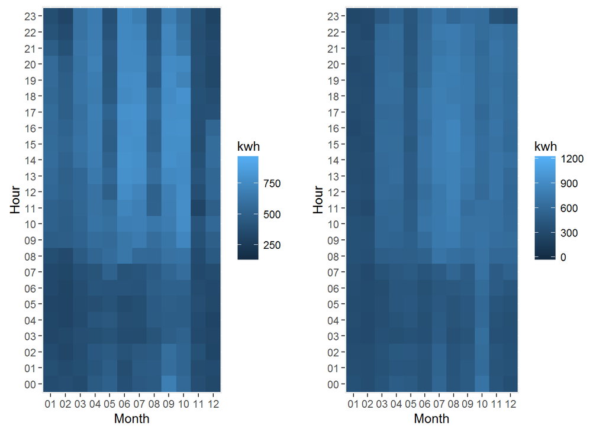

```r
# form a dataframe called eloadhrdf with two columns dates, kwh
# this dataframe sums the 15min kwh in the eloaddf to hourly data
# next create a plot frame with two panels side by side
# On the left panel show a heat map of kwh data for 2014 with x-axis as months and y-axis as hour of the day (1 to 24). use subsetting of the data frame rather than copying the data into yet another data frame
# On the right panel show a heat map of kwh data for 2015 with x-axis as months and y-axis as hour of the day (1 to 24). use subsetting of the data frame rather than copying the data into yet another data frame

# substract 1 to move the 24:00 time to previous hour
hour=cut(as.POSIXct(eloaddf$dates-1), "hour");

eloadhrdf = aggregate(eloaddf$kwh, list(hour), sum);
names(eloadhrdf) = c("dates", "kwh");

eloadhrdf$dates = as.POSIXct(strptime(eloadhrdf$dates, "%Y-%m-%d %H:%M:%S"), tz = "GMT");

# install ggplot2 for heat map
library(ggplot2)

idx.14 = which(format(eloadhrdf$dates, "%Y") == "2014")

gg14 = ggplot(data = eloadhrdf[idx.14, ], aes(x = format(dates, "%m"), y = format(dates, "%H"), fill = kwh)) + geom_tile() + xlab("Month") + ylab("Hour");

gg15 = ggplot(data = eloadhrdf[-idx.14, ], aes(x = format(dates, "%m"), y = format(dates, "%H"), fill = kwh)) + geom_tile() + xlab("Month") + ylab("Hour");

library(grid)
library(gridExtra)

grid.arrange(gg14, gg15, ncol = 2)
```

We plot the weather data using boxplot to explore the variation in temperature graphically

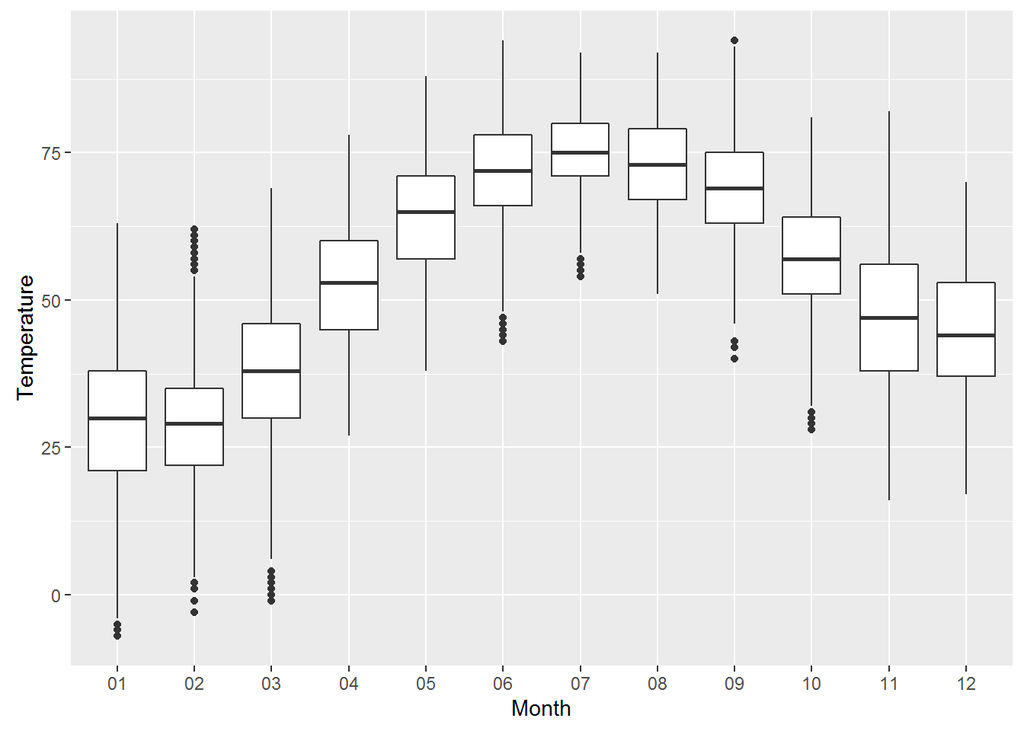

```r
# plot the weather data. Use boxplots in ggplot2 with month on the x-axis and temperature in y-axis

bp = ggplot(data = weatherdf, aes(x = format(weatherdf$dates, "%m"), y = TEMP)) + geom_boxplot() + xlab("Month") + ylab("Temperature")

bp
```

We are now ready to build a simple predictive model.

```r
#create a dataframe with hourly interval data inside your function by
# combining selective columns from eloadhrdf and weatherdf
# your dataframe should be called modeldatadf and the columns should be dates, year, month, hrofday, temp, kwh
#
hour=cut(as.POSIXct(weatherdf$dates), "hour");
hour = as.POSIXct(hour, tz = "GMT");
idx = which(!duplicated(hour) & format(weatherdf$dates, "%Y") != 2016);

# inner join
modeldatadf = merge(data.frame(dates = eloadhrdf$dates, kwh = eloadhrdf$kwh), data.frame(dates = hour[idx], temp = weatherdf$TEMP[idx]));

modeldatadf$year = as.factor(format(modeldatadf$dates, "%Y"));
modeldatadf$month = as.factor(format(modeldatadf$dates, "%m"));
modeldatadf$hrofday = as.factor(format(modeldatadf$dates, "%H"));

modeldatadf = modeldatadf[c(1, 4, 5, 6, 3, 2)];

#
# write a simple function called predmodel. the model object should be the return parameter
# pass in the appropriate data frames.
#
# you should fit a GLM with the following specification kwh ~ month + hrofday + temp
# your model should only use 2014 data for your prediction model
#
# use the summary function and display the results of the function

# use default gaussian family
premodel = function(data)
{
  glm.fit = glm(kwh ~ month + hrofday + temp, data = data, subset = year == 2014);

  return(glm.fit)
}

model.2014 = premodel(modeldatadf);
summary(model.2014)
```

```
##
## Call:
## glm(formula = kwh ~ month + hrofday + temp, data = data, subset = year ==
##     2014)
##
## Deviance Residuals:
##     Min       1Q   Median       3Q      Max
## -450.57   -60.67    19.57    76.32   523.78
##
## Coefficients:
##             Estimate Std. Error t value Pr(>|t|)
## (Intercept)  298.431      7.367  40.512  < 2e-16 ***
## month02        5.309      5.534   0.959 0.337455
## month03      -37.161      5.540  -6.708 2.10e-11 ***
## month04       52.358      6.182   8.470  < 2e-16 ***
## month05       57.782      6.969   8.292  < 2e-16 ***
## month06       77.431      7.752   9.988  < 2e-16 ***
## month07       63.873      8.010   7.975 1.73e-15 ***
## month08       82.106      7.707  10.654  < 2e-16 ***
## month09       95.216      7.398  12.870  < 2e-16 ***
## month10      153.962      6.597  23.337  < 2e-16 ***
## month11       60.520      5.757  10.512  < 2e-16 ***
## month12       14.385      5.587   2.575 0.010050 *
## hrofday01     -9.479      7.727  -1.227 0.219945
## hrofday02    -31.180      7.735  -4.031 5.60e-05 ***
## hrofday03    -63.210      7.733  -8.175 3.39e-16 ***
## hrofday04    -60.104      7.736  -7.769 8.79e-15 ***
## hrofday05    -63.104      7.745  -8.148 4.21e-16 ***
## hrofday06    -53.845      7.742  -6.955 3.79e-12 ***
## hrofday07    -29.979      7.745  -3.870 0.000109 ***
## hrofday08     46.353      7.749   5.982 2.30e-09 ***
## hrofday09     99.577      7.752  12.845  < 2e-16 ***
## hrofday10    114.503      7.736  14.802  < 2e-16 ***
## hrofday11    108.489      7.711  14.070  < 2e-16 ***
## hrofday12    115.433      7.705  14.982  < 2e-16 ***
## hrofday13    126.509      7.714  16.401  < 2e-16 ***
## hrofday14    130.039      7.737  16.807  < 2e-16 ***
## hrofday15    116.155      7.753  14.982  < 2e-16 ***
## hrofday16    120.745      7.783  15.513  < 2e-16 ***
## hrofday17    117.974      7.796  15.132  < 2e-16 ***
## hrofday18    113.768      7.806  14.574  < 2e-16 ***
## hrofday19    101.539      7.810  13.001  < 2e-16 ***
## hrofday20     97.777      7.792  12.548  < 2e-16 ***
## hrofday21     91.087      7.766  11.729  < 2e-16 ***
## hrofday22     66.818      7.745   8.628  < 2e-16 ***
## hrofday23     24.871      7.735   3.215 0.001307 **
## temp           2.332      0.127  18.360  < 2e-16 ***
## ---
## Signif. codes:  0 '***' 0.001 '**' 0.01 '*' 0.05 '.' 0.1 ' ' 1
##
## (Dispersion parameter for gaussian family taken to be 10714.41)
##
##     Null deviance: 203072536  on 8640  degrees of freedom
## Residual deviance:  92197540  on 8605  degrees of freedom
##   (118 observations deleted due to missingness)
## AIC: 104743
##
## Number of Fisher Scoring iterations: 2
```

In the year 2014 it seems that the model used the month of January and first hour of the day as the intercepts.

There is a decline in kwh in march and a steady increase after. There is a sharp increase in October and sharply drops after. This is obviously caused by changing of the seasons.

Now show you skills in Machine Learning!

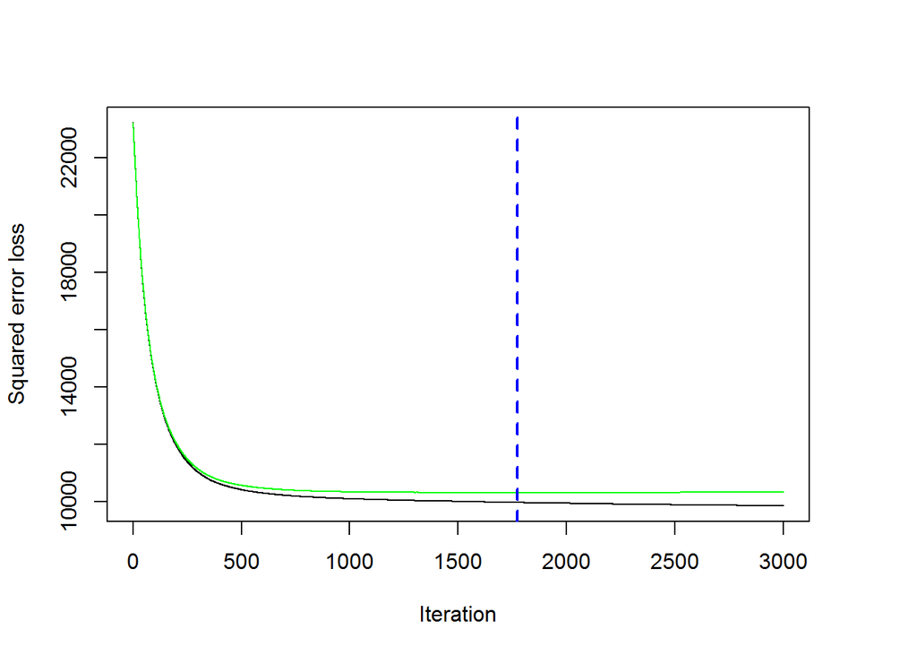

```r
#
# use the dataframe modeldatadf
# split it into training and testing data sets based on 2014 data for training and 2015 data for testing
# Use the GBM algorithm in the caret package in R to train and validate the model.
# You have free reign to display and explain your results graphically
#
#

library(gbm)
idx = which(modeldatadf$year == 2014);
train = modeldatadf[idx, 3:6];

# address of office
set.seed(6814);

gbm.fit = gbm(kwh ~ month + hrofday + temp, data = train, distribution = "gaussian", shrinkage = 0.01, interaction.dept = 2, var.monotone = c(0, 0, 1), n.trees = 3000, cv.folds = 10, verbose = T)
best.iter_train = gbm.perf(gbm.fit, method = "cv")
```

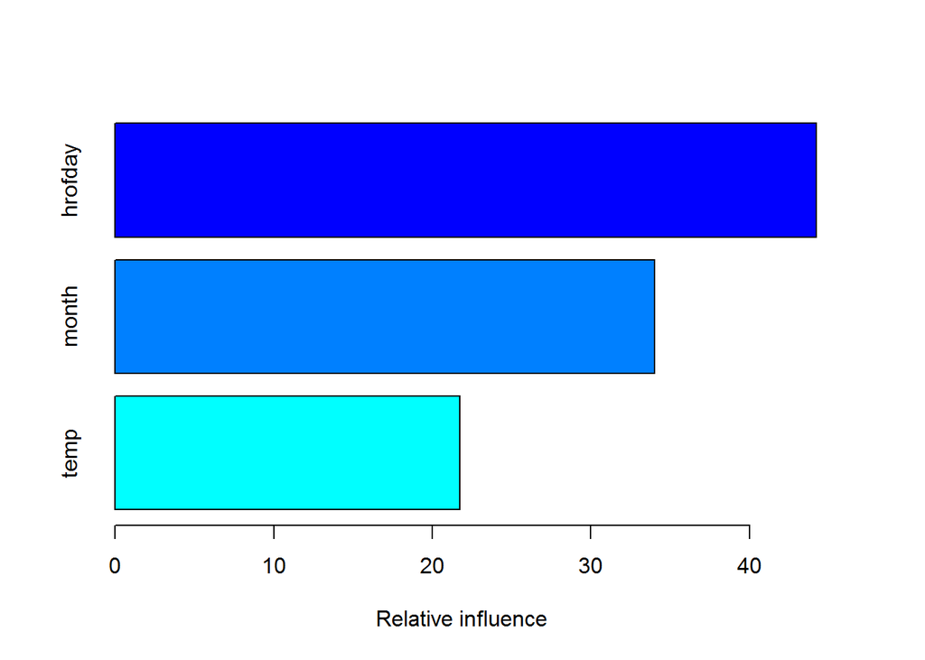

```
##             var  rel.inf
## hrofday hrofday 44.22943
## month     month 34.02809
## temp       temp 21.74248
```

```r
summary(gbm.fit)
```

```r
gbm.fit$cv.error[best.iter_train]
```

```
## [1] 10307.73
```

```r
gbm.fit$train.error[best.iter_train]
```

```
## [1] 9967.197
```

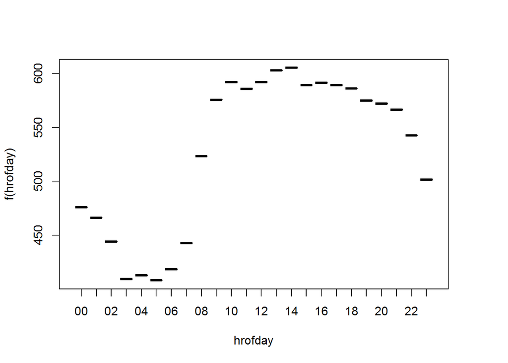

```r
plot(x = gbm.fit, i.var = "hrofday", n.trees = best.iter_train)
```

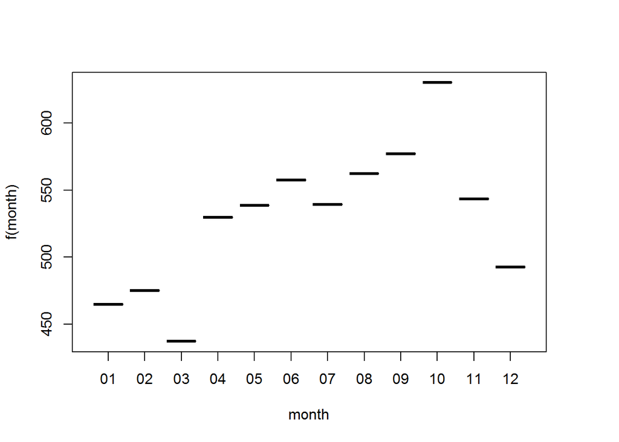

```r
plot(x = gbm.fit, i.var = "month", n.trees = best.iter_train)
```

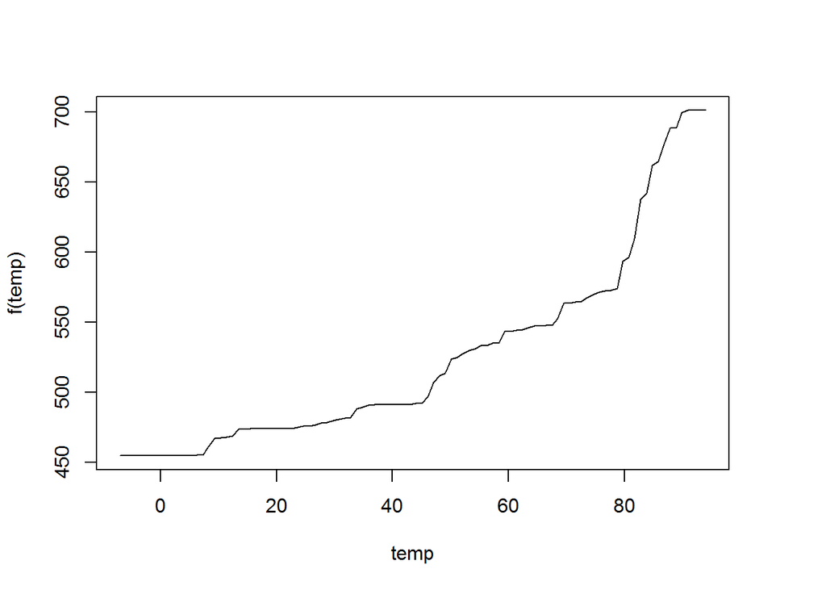

```r
plot(x = gbm.fit, i.var = "temp", n.trees = best.iter_train)
```

Lets now compare the predicted model for 2015 with the bill data kwh!

```r
#
# run your machine learning model and create a data frame of dates, kwh for 1hr interval data for 2015. note you
# may need to include the last few days of 2014 in your dataset due to the billing dates in January (see billdata.xlsx)
# call your data frame pred2015df.

idx = which(modeldatadf$dates >= as.POSIXct("2014-12-20 0:00:00 GMT", "%Y-%m-%d %H:%M:%S", tz = "GMT"));

pred2015df = modeldatadf[idx, ];

# now for each of the 12 rows (billing periods) in the billsdf, sum the kwh for the date range in each of the rows from pred2015df for the corresponding start and end of billing in billsdf

predkwh = predict(gbm.fit, pred2015df, type = "response", n.trees = best.iter_train);

# create a resultsdf which has billdate, predkwh (from pred2015df), actualkwh (from billsdf)

resultsdf = data.frame(dates = billsdf$billdate, predkwh = integer(12), actualkwh = billsdf$kwh);

idx = which(pred2015df$dates < as.POSIXct(billsdf$billstartdt[2]));
resultsdf$predkwh[1] = sum(pred2015df$kwh[idx])

for (i in 2:11)
{
  idx = which(pred2015df$dates >= as.POSIXct(billsdf$billstartdt[i]) &
              pred2015df$dates < as.POSIXct(billsdf$billstartdt[i+1]))
    resultsdf$predkwh[i] = sum(pred2015df$kwh[idx])
}

idx = which(pred2015df$dates >= as.POSIXct(billsdf$billstartdt[12]));
resultsdf$predkwh[12] = sum(pred2015df$kwh[idx])

resultsdf
```

```
##         dates  predkwh actualkwh
## 1  2015-01-01 405731.8     66460
## 2  2015-02-01 288052.5     41180
## 3  2015-03-01 308307.9     48860
## 4  2015-04-01 374578.1     65360
## 5  2015-05-01 372751.2     70020
## 6  2015-06-01 404520.6     86500
## 7  2015-07-01 436419.7     88500
## 8  2015-08-01 407357.6     80240
## 9  2015-09-01 411062.6     81160
## 10 2015-10-01 472736.6     73760
## 11 2015-11-01 437253.6     65740
## 12 2015-12-01 421056.3     64160
```

```r
# display the results
```

This completes this little exploration of energy load data. Thank You!